# Course Project

Hannah, Katya, and Diana

4/21/2017

### Starbucks data

```r
library(DataComputing)
```

```r
data("ZipDemography")
library(readr)
starbucks = read_csv("~/MATH 253/Math-253-Assignments1/starbucks.csv")
# Filter starbucks data set for only US
starbucks_us = subset(starbucks, Country =="US")

# Merged ZipDemography and Starbucks US data sets
Starbucks_zipcode = merge(ZipDemography, starbucks_us, by.x= "ZIP", by.y = "Postcode", all = TRUE)

# Subset including Starbucks in the US and needed variables
myvars = c("ZIP", "City", "State/Province", "Totalpopulation", "MedianAge", "Highschoolgraduateorhigher", "Bachelorsdegreeorhigher", "Foreignborn", "Meantraveltimetoworkinminutespopulation16yearsandolder", "Percapitaincomedollars")

Starbucks_subset =  subset(Starbucks_zipcode, Percapitaincomedollars != "NA", select=myvars)

# Rename columns
names(Starbucks_subset)[names(Starbucks_subset) == 'State/Province'] = 'State'
names(Starbucks_subset)[names(Starbucks_subset) == 'Meantraveltimetoworkinminutespopulation16yearsandolder'] = 'Worktraveltime'

# Add response column Starbucks - 1 if zipcode has Starbucks, 0 if it doesn't
Starbucks_final = Starbucks_subset
Starbucks_final$Starbucks = ifelse(is.na(Starbucks_subset$City), 0, 1)

# Reduce to only variables we need, get rid of na data
subset_vars = c("Totalpopulation", "MedianAge", "Highschoolgraduateorhigher", "Bachelorsdegreeorhigher", "Foreignborn", "Worktraveltime", "Percapitaincomedollars", "Starbucks")
Starbucks_final = na.omit(subset(Starbucks_final, select = subset_vars))

#View(Starbucks_final)
```

### Train and Test Set

```r
set.seed(1)
train_range = sample(nrow(Starbucks_final), nrow(Starbucks_final) / 2)
test_range = (-train_range)
Starbucks.train = Starbucks_final[train_range, ]
Starbucks.test = Starbucks_final[test_range, ]

# Choose 15,000 as a size for both train and test set
train = sample(Starbucks.train, 15000)
#View(train)
test = sample(Starbucks.test, 15000)
```

### Logistic Regression

```r
logit.fit = glm(Starbucks ~ Totalpopulation + MedianAge + Highschoolgraduateorhigher + Bachelorsdegreeorhigher + Foreignborn + Worktraveltime + Percapitaincomedollars, data = train, family = "binomial")
logit.probs = predict(logit.fit, newdata = test, type = "response")
logit.pred = ifelse(logit.probs > 0.5, 1, 0)
table (logit.pred, test$Starbucks)
```

```
##
## logit.pred     0     1
##          0 12771  1188
##          1   435   606
```

```r
mean(logit.pred != test$Starbucks)
```

```
## [1] 0.1082
```

#### Logistic Regression using constant

```r
logit.fit2 = glm(Starbucks ~ 0, data = train, family = "binomial")
logit.probs2 = predict(logit.fit2, newdata = test, type = "response")
logit.pred2 = ifelse(logit.probs2 > 0.5, 1, 0)
table (logit.pred2, test$Starbucks)
```

```
##
## logit.pred2     0     1
##           0 13206  1794
```

```r
mean(logit.pred2 != test$Starbucks)
```

```
## [1] 0.1196
```

Using logistic regression, we have a classification error of 0.1082.

### Regression Tree

```r
library (tree)
# Ask about classification tree
tree_train = train
tree_train$StarbucksYes = ifelse(tree_train$Starbucks == 0, "No", "Yes")
tree_test = test
tree_test$StarbucksYes = ifelse(tree_test$Starbucks == 0, "No", "Yes")
#Regression Tree
tree.starbucks = tree(Starbucks ~ Totalpopulation + MedianAge + Highschoolgraduateorhigher + Bachelorsdegreeorhigher + Foreignborn + Worktraveltime + Percapitaincomedollars, data = train, method = "class")
summary(tree.starbucks)
```

```
##
## Regression tree:
## tree(formula = Starbucks ~ Totalpopulation + MedianAge + Highschoolgraduateorhigher +
##     Bachelorsdegreeorhigher + Foreignborn + Worktraveltime +
##     Percapitaincomedollars, data = train, method = "class")
## Variables actually used in tree construction:
## [1] "Bachelorsdegreeorhigher" "Foreignborn"
## Number of terminal nodes:  4
## Residual mean deviance:  0.07004 = 1050 / 15000
## Distribution of residuals:
##     Min.  1st Qu.   Median     Mean  3rd Qu.     Max.
## -0.59940 -0.01143 -0.01143  0.00000 -0.01143  0.98860
```

We are able to fit a regression tree to our data as we classified a zipcode having a Starbucks using 0s and 1s. It appears that only two of the variables have been used in constructing the tree: Bachelorsdegreeorhigher and Foreignborn.

Plot of tree:

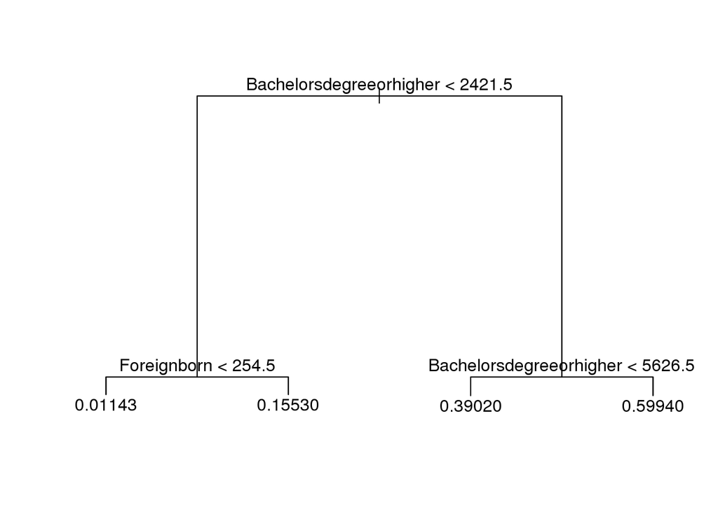

```r
plot(tree.starbucks)
text(tree.starbucks, pretty = 0)
```

From our tree plot, we recognize that if a given zipcode has less than 2421.5 people with bachelors degree and higher and less than 254.5 foreignborn, there is a 0.01143 percent chance that there is a Starbucks. Similarily, if a zipcode has less than 2421.5 people with bachelors degree and higher and more than 254.5 foreignborn, there is a 0.15530 percent chance that there is a Starbucks. If there are more than 2421.5 people with bachelors degree but less than 5626.5 people, there is a 0.39020 percent chance that there is a Starbucks. Lastly, if there are more than 5626.5 people with bachelors degree there is a 0.59940 that there is a Starbucks. Thus, we most likely to have a Starbucks in a zipcode that has more than 5626.5 people with a bachelors degree.

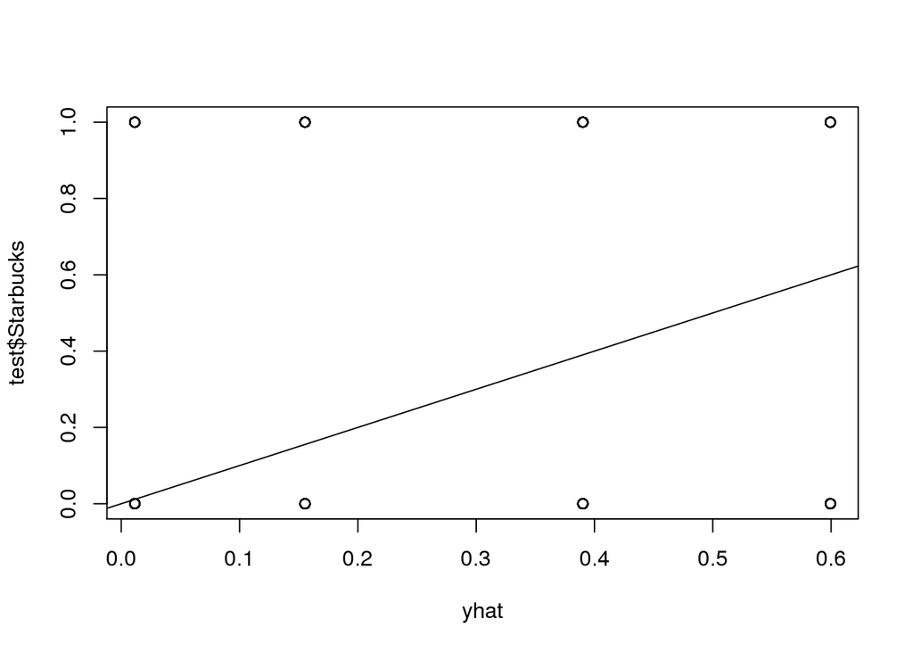

```r
yhat = predict(tree.starbucks, newdata = test)
plot(yhat, test$Starbucks)
abline(0,1)
```

```r
mean((yhat - test$Starbucks)^2)
```

```
## [1] 0.07076347
```

Regression tree error rate = 0.07076347.

### LDA

```r
library(MASS)
lda.fit = lda(Starbucks ~ Totalpopulation + MedianAge + Highschoolgraduateorhigher + Bachelorsdegreeorhigher + Foreignborn + Worktraveltime + Percapitaincomedollars, data = train)
lda.fit
```

```
## Call:
## lda(Starbucks ~ Totalpopulation + MedianAge + Highschoolgraduateorhigher +
##     Bachelorsdegreeorhigher + Foreignborn + Worktraveltime +
##     Percapitaincomedollars, data = train)
##
## Prior probabilities of groups:
##         0         1
## 0.8787333 0.1212667
##
## Group means:
##   Totalpopulation MedianAge Highschoolgraduateorhigher
## 0         6995.41  37.92382                   3544.512
## 1        28493.05  35.13293                  15695.389
##   Bachelorsdegreeorhigher Foreignborn Worktraveltime
## 0                946.5138    663.9326       26.36936
## 1               6098.7763   4221.3623       24.41765
##   Percapitaincomedollars
## 0               18057.40
## 1               26255.23
##
## Coefficients of linear discriminants:
##                                      LD1
## Totalpopulation            -1.482742e-05
## MedianAge                  -3.922135e-02
## Highschoolgraduateorhigher  1.152369e-04
## Bachelorsdegreeorhigher     1.280089e-04
## Foreignborn                 1.678175e-05
## Worktraveltime             -1.094972e-02
## Percapitaincomedollars      2.882950e-05
```

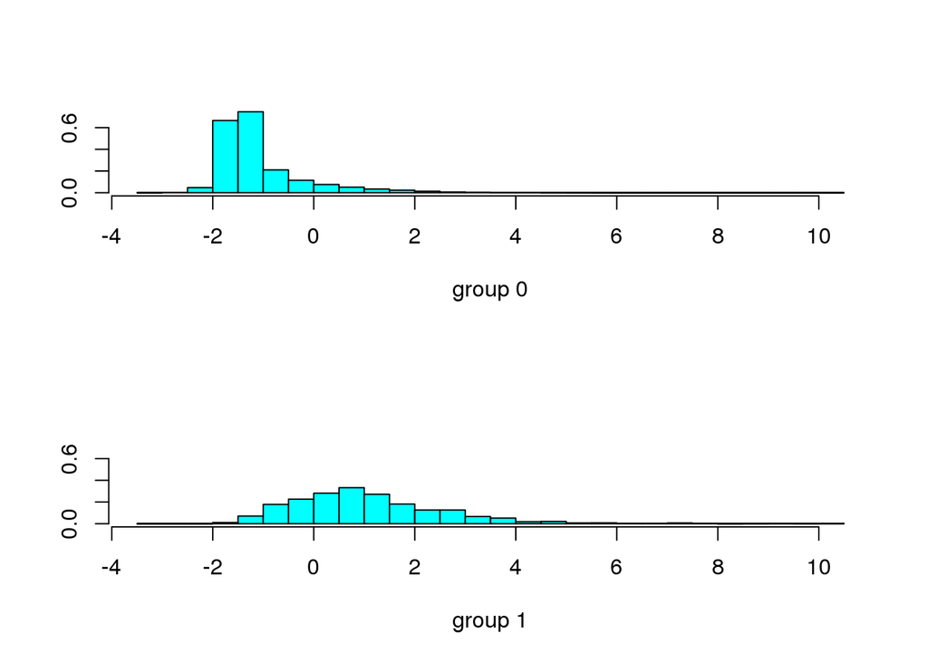

```r
plot(lda.fit)
```

Horizontal axis is linear combination of all of our explanatory variables. This is the linear combination where the two groups (0,1) are most different.

Thus, we know that 87.87 % of the training observations correspond to zipcodes that do not have Starbucks and 12.13 % of the training observations correspond to zipcodes that have Starbucks.

```r
lda.pred = predict(lda.fit, test)
lda.class = lda.pred$class
table(lda.class, test$Starbucks)
```

```
##
## lda.class     0     1
##         0 12552   983
##         1   654   811
```

```r
mean(lda.class != test$Starbucks)
```

```
## [1] 0.1091333
```

With LDA, we get an error rate of 0.1091333.

### QDA

```r
library(MASS)
qda.fit = qda(Starbucks ~ Totalpopulation + MedianAge + Highschoolgraduateorhigher + Bachelorsdegreeorhigher + Foreignborn + Worktraveltime + Percapitaincomedollars, data = train)
qda.fit
```

```
## Call:
## qda(Starbucks ~ Totalpopulation + MedianAge + Highschoolgraduateorhigher +
##     Bachelorsdegreeorhigher + Foreignborn + Worktraveltime +
##     Percapitaincomedollars, data = train)
##
## Prior probabilities of groups:
##         0         1
## 0.8787333 0.1212667
##
## Group means:
##   Totalpopulation MedianAge Highschoolgraduateorhigher
## 0         6995.41  37.92382                   3544.512
## 1        28493.05  35.13293                  15695.389
##   Bachelorsdegreeorhigher Foreignborn Worktraveltime
## 0                946.5138    663.9326       26.36936
## 1               6098.7763   4221.3623       24.41765
##   Percapitaincomedollars
## 0               18057.40
## 1               26255.23
```

```r
qda.pred = predict(qda.fit, test)
qda.class = qda.pred$class
table(qda.class, test$Starbucks)
```

```
##
## qda.class     0     1
##         0 12173   848
##         1  1033   946
```

```r
mean(qda.class != test$Starbucks)
```

```
## [1] 0.1254
```

With QDA, we get an error rate of 0.1254.

### KNN

```r
library(class)
knn.pred1 = knn(train, test, train$Starbucks, k = 1)

table(knn.pred1, test$Starbucks)
```

```
##
## knn.pred1     0     1
##         0 12185   904
##         1  1021   890
```

```r
mean(test$Starbucks != knn.pred1)
```

```
## [1] 0.1283333
```

KNN w/ K = 1 Error Rate = 0.1283333

```r
knn.pred5 = knn(train, test, train$Starbucks, k = 5)

table(knn.pred5, test$Starbucks)
```

```
##
## knn.pred5     0     1
##         0 12526  1027
##         1   680   767
```

```r
mean(test$Starbucks != knn.pred5)
```

```
## [1] 0.1138
```

KNN w/ K = 5 Error Rate = 0.1138

```r
knn.pred10 = knn(train, test, train$Starbucks, k = 10)

table(knn.pred10, test$Starbucks)
```

```
##
## knn.pred10     0     1
##          0 12621  1099
##          1   585   695
```

```r
mean(test$Starbucks != knn.pred10)
```

```
## [1] 0.1122667
```

```r
knn.pred100 = knn(train, test, train$Starbucks, k = 100)

table(knn.pred100, test$Starbucks)
```

```
##
## knn.pred100     0     1
##           0 12713  1129
##           1   493   665
```

```r
mean(test$Starbucks != knn.pred100)
```

```
## [1] 0.1081333
```

### Bagging

```r
library(randomForest)
set.seed(1)
bag.starbucks = randomForest(Starbucks ~ Totalpopulation + MedianAge + Highschoolgraduateorhigher + Bachelorsdegreeorhigher + Foreignborn + Worktraveltime + Percapitaincomedollars, data = train, mtry = 7)
bag.starbucks
```

```
##
## Call:
##  randomForest(formula = Starbucks ~ Totalpopulation + MedianAge +      Highschoolgraduateorhigher + Bachelorsdegreeorhigher + Foreignborn +      Worktraveltime + Percapitaincomedollars, data = train, mtry = 7)
##                Type of random forest: regression
##                      Number of trees: 500
## No. of variables tried at each split: 7
##
##           Mean of squared residuals: 0.05868124
##                     % Var explained: 44.93
```

```r
yhat.bag = predict(bag.starbucks, newdata = test)
mean((yhat.bag - test$Starbucks)^2)
```

```
## [1] 0.06079823
```

The test MSE associated with the bagged regression tree is 0.06079823.

### Random Forests

```r
set.seed(1)
rf.starbucks = randomForest(Starbucks ~ Totalpopulation + MedianAge + Highschoolgraduateorhigher + Bachelorsdegreeorhigher + Foreignborn + Worktraveltime + Percapitaincomedollars, data = train, mtry = 2)
yhat.rf = predict(rf.starbucks, newdata = test)
mean((yhat.rf - test$Starbucks)^2)
```

```
## [1] 0.05928749
```

The test MSE associated with the random forest is 0.05928749.